# EDA y Clustering sobre dataset de Spotify

Agustin MiÃ±an Valero

## Spotify

Aclaracion sobre preprocesamiento:

- Se ajustan los rankings para que hayan 50 canciones por pais.
- Se eliminan los repetidos en Venezuela
- Se ajusta la feature duracion para que estÃ© en segundos

El dataset de spotify tiene 22 variables para 900 canciones, las cuales estan divididas en 18 paises, con un top 50 de cada uno:

Las variables son:

cancion_nombre, cancion_popularidad, cancion_artista, cancion_artista_completo, cancion_album, cancion_numero, pais_nombre, feature_bailabilidad, feature_energia, feature_clave, feature_fuerza, feature_modo, feature_hablado, feature_acustico, feature_instrumental, feature_en_vivo, feature_positividad, feature_tempo, feature_duracion, feature_tiempo_compas, album_fecha

# Resumen de datos

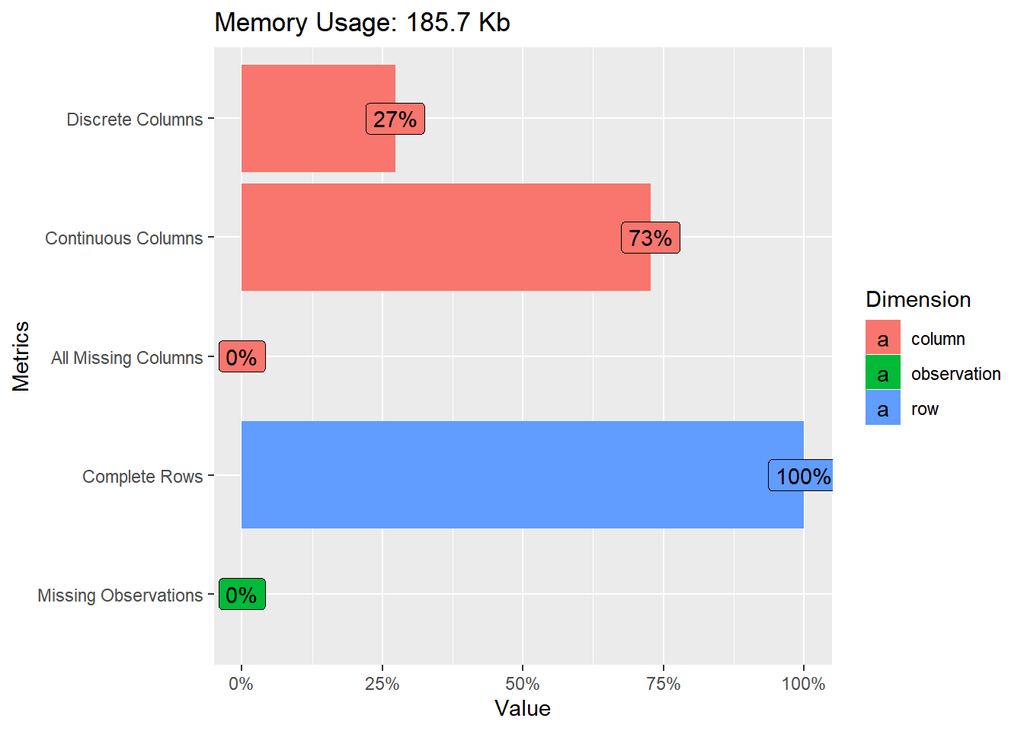

```r
plot_intro(csv)
```

Como se puede observar, no tenemos filas incompletas ni observaciones faltantes, lo que facilita el procesamiento de datos ya que no hay que lidiar con datos faltantes

# Variables

SÃ³lo se detallan las que no se describen con su nombre:

cancion_popularidad: Popularidad medida en Spotify

cancion_numero: Orden de la cancion en el ranking

pais_nombre: PaÃs del ranking

feature_clave: Es la nota musical

feature_fuerza: Es el volumen promedio de una cancion

feature_modo: Indica el tono (mayor o menor) sobre la nota musical de una cancion

Las variables feature_bailabilidad, feature_energia, feature_positividad son generadas por spotify y no sabe con exactitud como son calculadas

# Paises

Listado de paÃses ordenados alfabeticamente

```r
unique(csv$pais_nombre)[order(unique(csv$pais_nombre))]
```

```
##  [1] Argentina               Bolivia
##  [3] Chile                   Colombia
##  [5] Costa Rica              Ecuador
##  [7] El Salvador             EspaÃ±a
##  [9] Guatemala               Honduras
## [11] la Republica Dominicana MÃ©xico
## [13] Nicaragua               PanamÃ¡
## [15] Paraguay                PerÃº
## [17] Uruguay                 Venezuela
## 18 Levels: Argentina Bolivia Chile Colombia Costa Rica ... Venezuela
```

# Canciones

Listado de canciones ordenadas alfabeticamente

```r
unique(csv$cancion_nombre)[order(unique(csv$cancion_nombre))]
```

```
##   [1] Â¿Quien Tu Eres?
##   [2] 11 PM
##   [3] 200 Mph
##   [4] 22
##   [5] 7 rings
##   [6] A Solas - Remix
##   [7] A TravÃ©s Del Vaso
##   [8] Adan y Eva
##   [9] Adictiva
##  [10] AdiÃ³s Amor
##  [11] AerolÃnea Carrillo
##  [12] Ahora Te Puedes Marchar
##  [13] All I Want for Christmas Is You
##  [14] Amanece
##  [15] Amigos Con Derechos
```

[output cut: 197 more lines]

# Artistas

Listado de artistas principales ordenados alfabeticamente

```r
unique(csv$cancion_artista)[order(unique(csv$cancion_artista))]
```

```
##   [1] 6ix9ine
##   [2] Agus Padilla
##   [3] Albert Gonzalez
##   [4] Aleman
##   [5] Alex Rose
##   [6] Amenazzy
##   [7] AndrÃ©s Cepeda
##   [8] Anuel Aa
##   [9] Ariana Grande
##  [10] Bad Bunny
##  [11] Banda Sinaloense MS de Sergio LizÃ¡rraga
##  [12] Becky G
##  [13] benny blanco
##  [14] Beret
##  [15] Bhavi
```

[output cut: 107 more lines]

# Correlacion entre variables

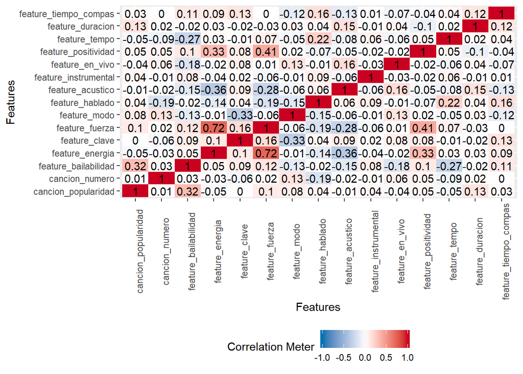

```r
csv_cancionesunicas <- csv %>% distinct(cancion_nombre, .keep_all = TRUE)
plot_correlation(csv_cancionesunicas[-1], type="c")
```

En el grÃ¡fico se puede observar lo siguiente:

- **Fuerza** (Volumen) y **Energia** estan altamente relacionadas (0.72)
- **Fuerza** y **Positividad** estan relacionadas (0.41)
- **Energia** y **Positividad** estan relacionadas (0.33)
- **Bailabilidad** y **Popularidad** estan relacionadas (0.32)
- **Acustico** y **Energia** estan inversamente relacionadas (-0.36)
- **Modo** y **Clave** estan inversamente relacionadas (-0.33)
- **Acustico** y **Fuerza** estan inversamente relacionadas (-0.28)
- **Tempo** y **Bailabilidad** estan inversamente relacionadas (-0.27)

## Correlaciones particulares

Vistas las relaciones dadas en el grafico anterior, procedo a mostrar graficamente los pares de valores relacionados

### Relacionadas

#### Fuerza y energia

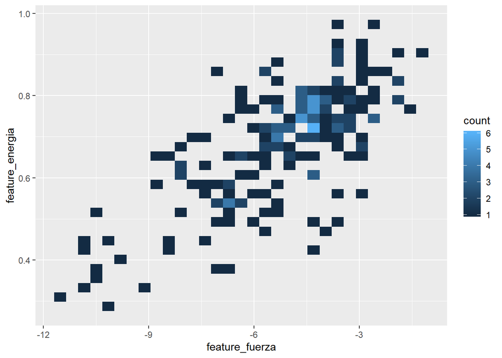

```r
ggplot(data = csv_cancionesunicas) + geom_bin2d(mapping = aes(x = feature_fuerza, y = feature_energia))
```

#### Fuerza y positividad

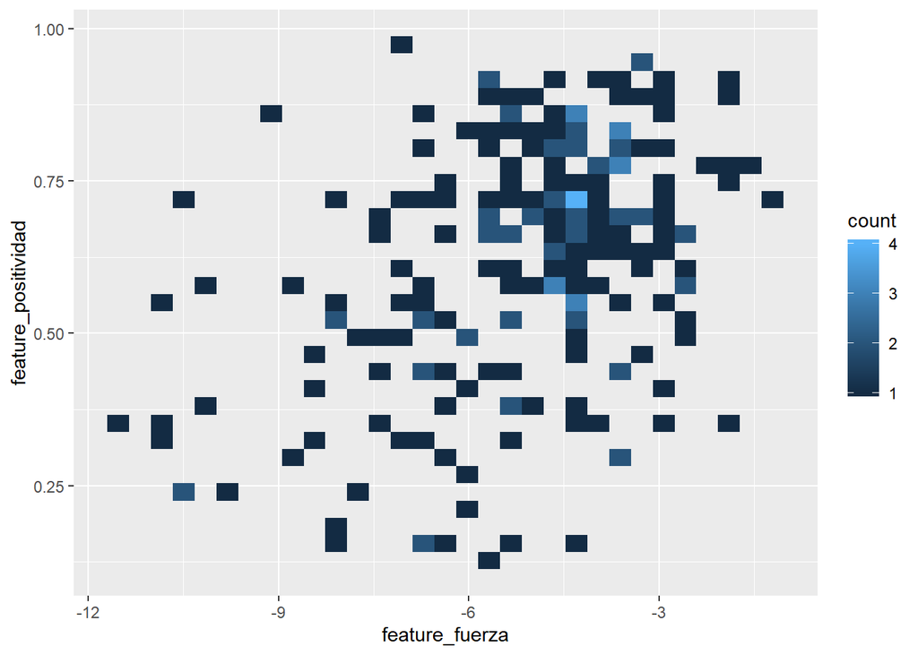

```r
ggplot(data = csv_cancionesunicas) + geom_bin2d(mapping = aes(x = feature_fuerza, y = feature_positividad))
```

#### Energia y positividad

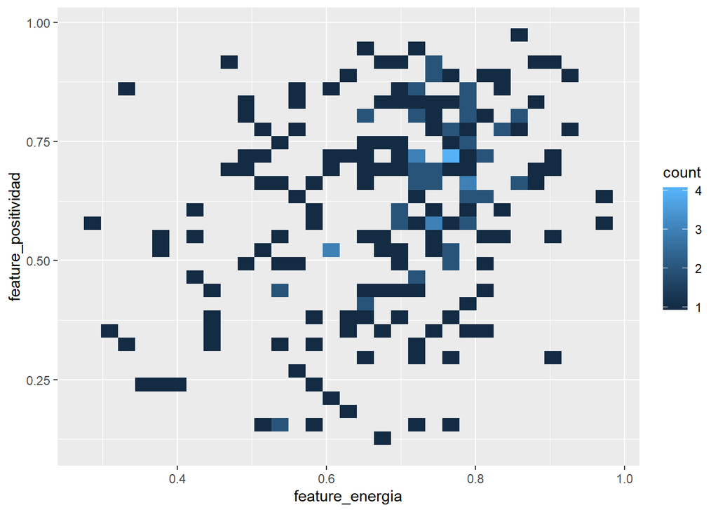

```r
ggplot(data = csv_cancionesunicas) + geom_bin2d(mapping = aes(x = feature_energia, y = feature_positividad))
```

#### Bailabilidad y Popularidad

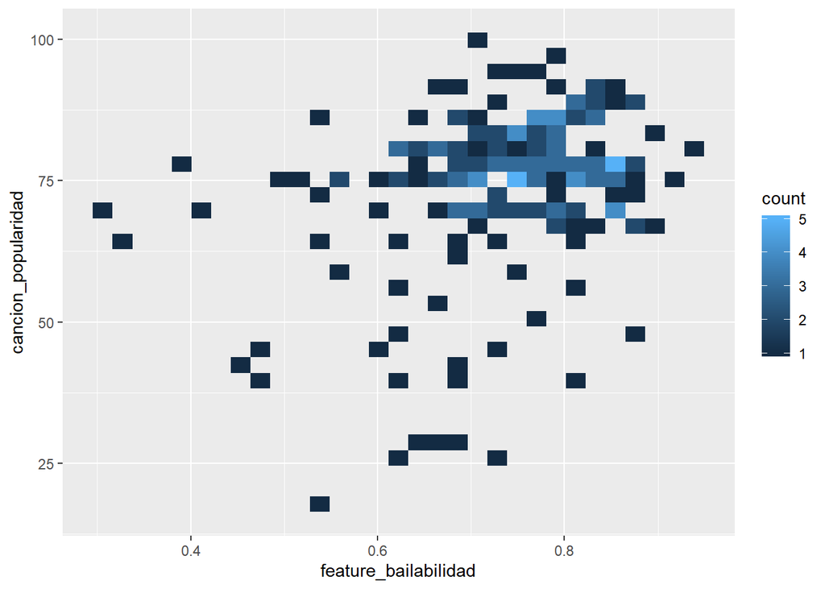

```r
ggplot(data = csv_cancionesunicas) + geom_bin2d(mapping = aes(x = feature_bailabilidad, y = cancion_popularidad))
```

### Inversamente relacionadas

#### Acustico y energia

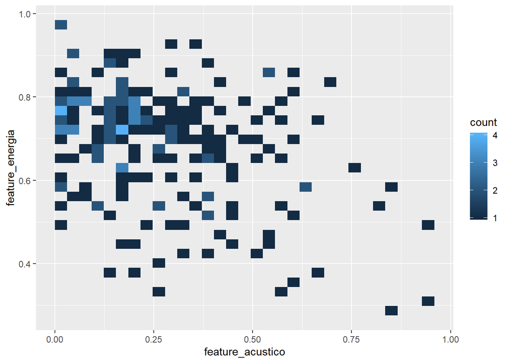

```r
ggplot(data = csv_cancionesunicas) + geom_bin2d(mapping = aes(x = feature_acustico, y = feature_energia))
```

#### Acustico y Fuerza

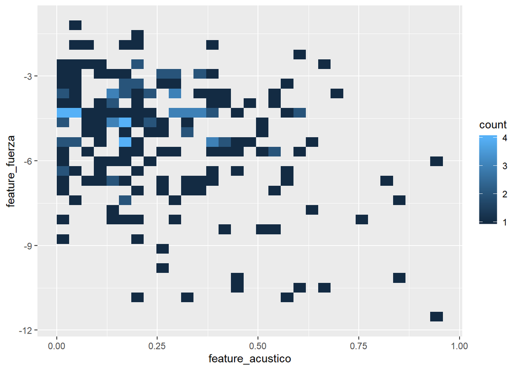

```r
ggplot(data = csv_cancionesunicas) + geom_bin2d(mapping = aes(x = feature_acustico, y = feature_fuerza))
```

#### Tempo y Bailabilidad

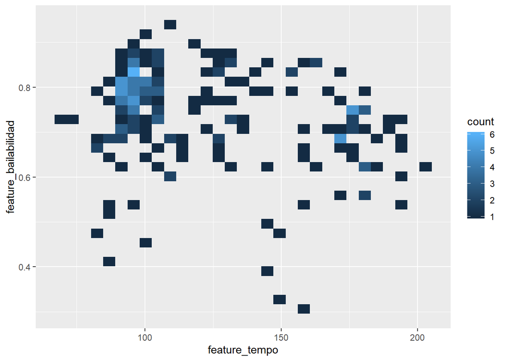

```r
ggplot(data = csv_cancionesunicas) + geom_bin2d(mapping = aes(x = feature_tempo, y = feature_bailabilidad))
```

## Anexo: Relacion entre duracion y popularidad

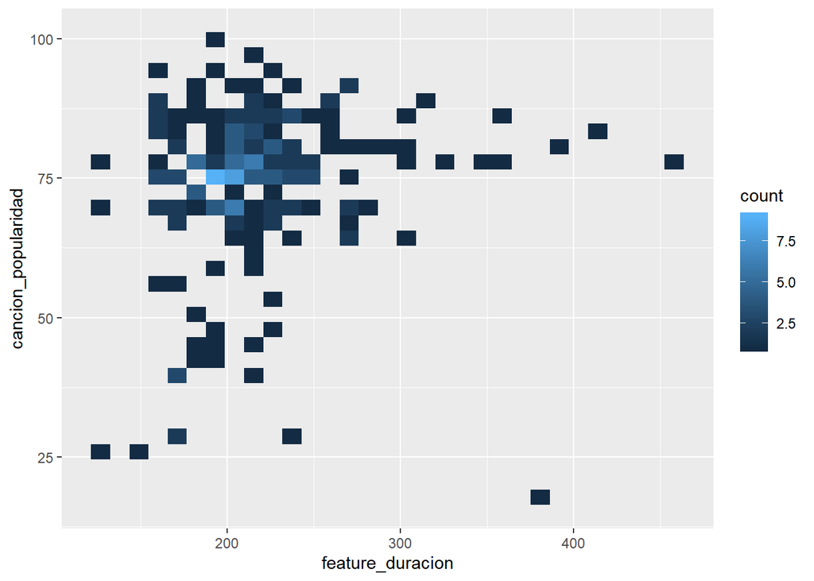

```r
ggplot(data = csv_cancionesunicas) + geom_bin2d(mapping = aes(x = feature_duracion, y = cancion_popularidad))
```

# Distribucion de los valores

Solamente de los valores numericos

```r
csv_numerico <- csv_cancionesunicas[,-c(1,2,4,5,6,7,8,22)]
summary(csv_numerico)
```

```
##  cancion_popularidad feature_bailabilidad feature_energia
##  Min.   : 18.00      Min.   :0.3000       Min.   :0.2870
##  1st Qu.: 70.00      1st Qu.:0.6850       1st Qu.:0.5995
##  Median : 76.00      Median :0.7540       Median :0.7170
##  Mean   : 74.22      Mean   :0.7373       Mean   :0.6882
##  3rd Qu.: 82.00      3rd Qu.:0.8070       3rd Qu.:0.7825
##  Max.   :100.00      Max.   :0.9330       Max.   :0.9740
##  feature_clave    feature_fuerza     feature_modo    feature_hablado
##  Min.   : 0.000   Min.   :-11.420   Min.   :0.0000   Min.   :0.02810
##  1st Qu.: 1.500   1st Qu.: -6.338   1st Qu.:0.0000   1st Qu.:0.05385
##  Median : 6.000   Median : -4.716   Median :1.0000   Median :0.10000
##  Mean   : 5.436   Mean   : -5.148   Mean   :0.5687   Mean   :0.12995
##  3rd Qu.: 8.000   3rd Qu.: -3.724   3rd Qu.:1.0000   3rd Qu.:0.17200
##  Max.   :11.000   Max.   : -1.098   Max.   :1.0000   Max.   :0.50000
##  feature_acustico  feature_instrumental feature_en_vivo
##  Min.   :0.00513   Min.   :0.000e+00    Min.   :0.01610
##  1st Qu.:0.11700   1st Qu.:0.000e+00    1st Qu.:0.08715
##  Median :0.21300   Median :0.000e+00    Median :0.10800
##  Mean   :0.26488   Mean   :3.831e-03    Mean   :0.15474
##  3rd Qu.:0.38250   3rd Qu.:2.185e-05    3rd Qu.:0.16600
##  Max.   :0.93300   Max.   :3.120e-01    Max.   :0.89200
##  feature_positividad feature_tempo    feature_duracion
##  Min.   :0.1170      Min.   : 70.14   Min.   :125.7
##  1st Qu.:0.4895      1st Qu.: 94.56   1st Qu.:188.6
##  Median :0.6510      Median :105.94   Median :208.1
##  Mean   :0.6174      Mean   :122.88   Mean   :216.3
##  3rd Qu.:0.7765      3rd Qu.:154.98   3rd Qu.:231.2
##  Max.   :0.9630      Max.   :203.93   Max.   :456.9
##  feature_tiempo_compas
##  Min.   :3.000
##  1st Qu.:4.000
##  Median :4.000
##  Mean   :3.986
##  3rd Qu.:4.000
##  Max.   :5.000
```

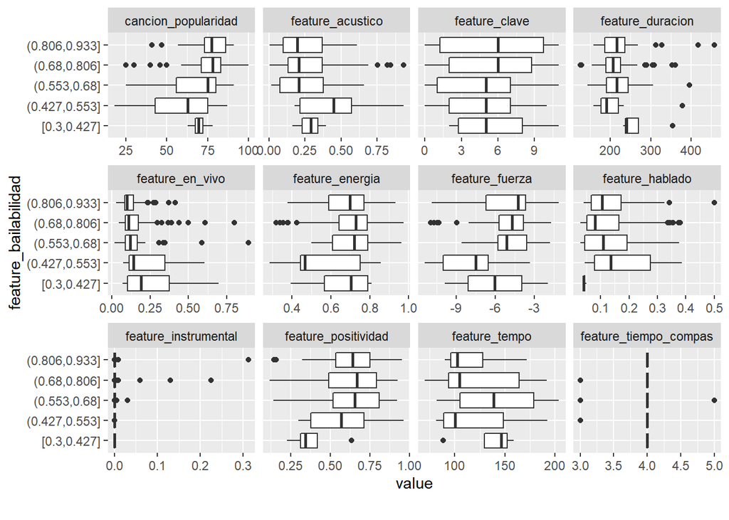

```r
plot_boxplot(csv_numerico, by="feature_bailabilidad")
```

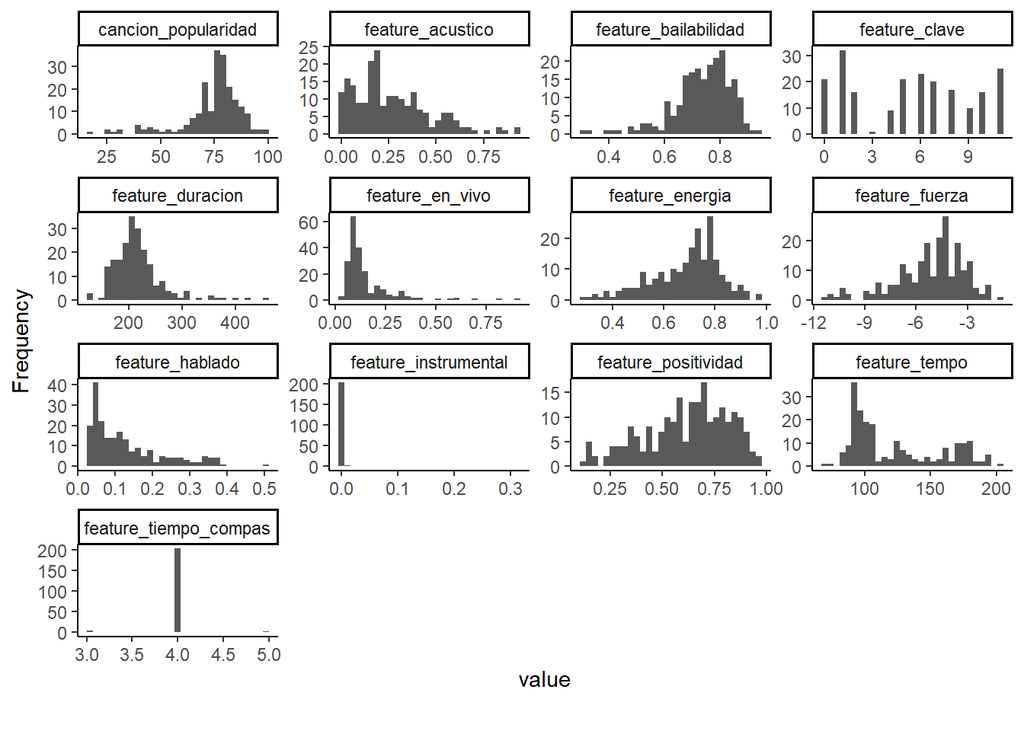

```r
plot_histogram(csv_numerico,ggtheme=theme_classic())
```

# Clustering

Se hara una separacion en clusters a las variables bailabilidad y popularidad, para poder separar a las canciones en estos grupos

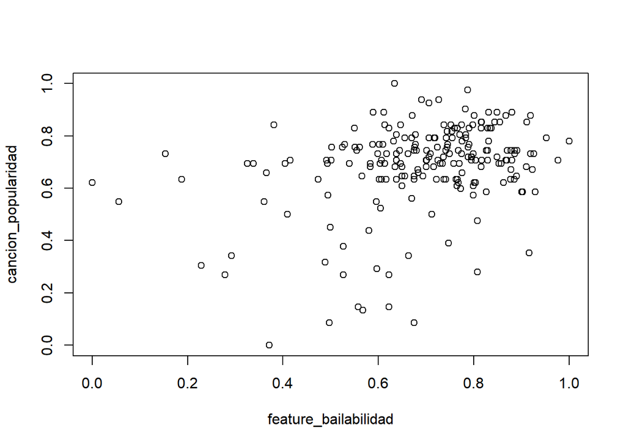

```r
escala <- function(ds){
  x.max = max(ds[,1])
  x.min = min(ds[,1])
  y.max = max(ds[,2])
  y.min = min(ds[,2])

  for (i in 1:nrow(ds)) {
    ds[i,1] <- (ds[i,1] - x.min)/(x.max-x.min)
    ds[i,2] <- (ds[i,2] - y.min)/(y.max-y.min)
  }
  ds
}
csv_cluster <- csv_cancionesunicas[,c("cancion_nombre","feature_bailabilidad","cancion_popularidad")]
csv_cluster[,2:3] <- escala(csv_cluster[,2:3])
plot(csv_cluster[,-1])
```

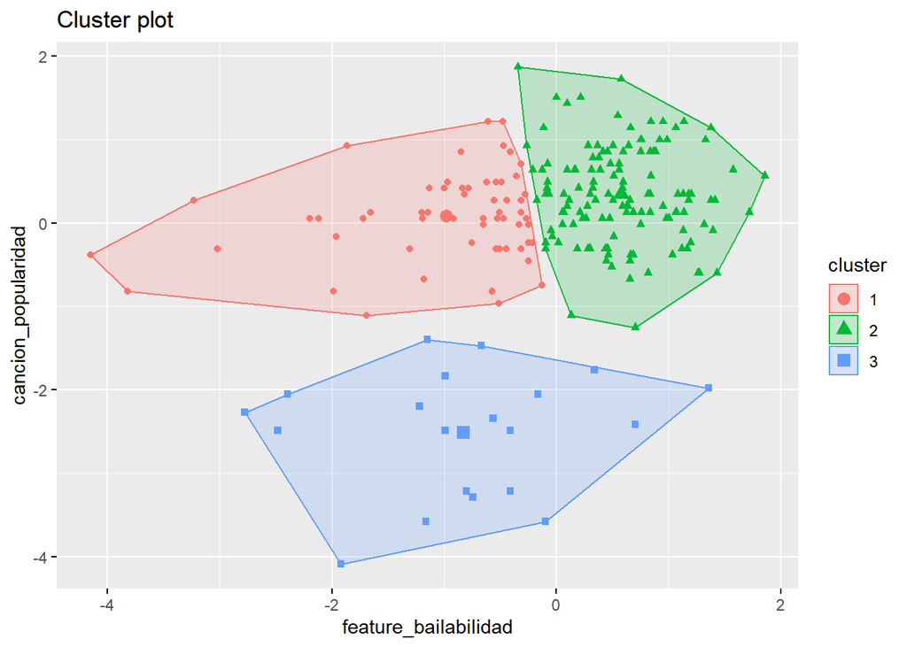

```r
set.seed(2111)
km <- kmeans(csv_cluster[,-1], 3)
fviz_cluster(km, csv_cluster[,-1], geom = "point")
```

```r
csv_cluster[,4] <- km$cluster
colnames(csv_cluster)[4] <- "cluster"
```

## Cluster 1: Popular no tan bailable

```r
csv_cluster[csv_cluster$cluster == 1,][1]
```

```
##                                                       cancion_nombre
## 15                                       Sin Culpa (feat. DrefQuila)
## 18                                                            Me Voy
## 19                                                 Ya No Tiene Novio
## 32                                                              Sola
## 35                                               Amigos Con Derechos
## 37                                       Me Vas a ExtraÃ±ar - En Vivo
## 40                                             BEBE (feat. Anuel Aa)
## 41                                                       No Es Justo
## 46                                                         Luz Apaga
## 52                                                     Pa MÃ - Remix
## 55                                                              Caro
## 56                                                         La Romana
## 57                                            Si EstuviÃ©semos Juntos
## 59                                                         Te RobarÃ©
```

[output cut: 46 more lines]

## Cluster 2: Popular y Bailable

```r
csv_cluster[csv_cluster$cluster == 2,][1]
```

```
##                                                                                                                  cancion_nombre
## 1                                                                                                                 Calma - Remix
## 3                                                                                                                    Adan y Eva
## 4                                                                                                                     Con Calma
## 6                                                                                                                       Secreto
## 7                                                                                                                  Desconocidos
## 8                                                                                                             Baila Baila Baila
## 10                                                                                                                    Reggaeton
## 11                                                                                                            MIA (feat. Drake)
## 12                                                                                                                     Adictiva
## 13                                                                                                                      Amanece
## 14                                                                               Taki Taki (with Selena Gomez, Ozuna & Cardi B)
## 16                                                                                                                        Te Vi
## 17                                                                                                                    Imposible
## 20                                                                                                                       Un AÃ±o
```

[output cut: 117 more lines]

## Cluster 3: Poco popular

```r
csv_cluster[csv_cluster$cluster == 3,][1]
```

```
##                         cancion_nombre
## 2                                 Hope
## 5                            QuÃ© pasÃ³?
## 9                                 Tuyo
## 25         LeÃ±a para el CarbÃ³n - Remix
## 45                             Control
## 54                              Tiempo
## 60                        Lo Prohibido
## 68             Me Ignoras (feat. Kayl)
## 92  Apagar la luz (feat. Gustavo Elis)
## 94                          I Remember
## 97            Pon Dem (Dancehall Edit)
## 98                            De Beber
## 103                       Someone Else
## 111                           Lollipop
## 114                       Quiere Beber
## 116                   Te Gusta Hacerla
## 127                      Feliz Navidad
## 134                       Toda - Remix
## 157                              Ganas
## 166                      Feel The Gold
```